# 🪐 ¿Cuál será nuestro próximo destino? 🪐 Exoplanetas, la salvación de la humanidad

Por: Francisca Vilca Sánchez

01/12/2021

# *Introducción*

El Universo en el que vives es inmensamente grande y la comprensión que se tiene de este es practicamente nula. Sin embargo, gracias al conocimiento científico se ha logrado cada día avanzar un poco más en entender cómo funciona este. Una de las ramas que se está estudiando es el descubrimiento de exoplanetas, que son aquellos planetas que giran alrededor de otra estrella que no es el Sol del Sistema Solar, es decir, prácticamente la búsqueda de nuevos mundos a través del Universo.

Se deben preguntar por qué es interesante hablar sobre otros mundos que están a miles de millones de kilómetros de nosotros, y la respuesta es bastante simple. A pesar de la distancia que los separa, conocer otros exoplanetas será de gran ayuda para tener una mejor comprensión de nuestro propio Sistema Solar, y por consiguiente, de La Tierra. Además, a lo largo del último tiempo, el cambio climático y el calentamiento global han ido en aumento, lo que hace de nuestro hogar, cada día que pasa un lugar menos habitable para los seres vivos. Por ello, las grandes potencias mundiales comenzaron a buscar otras opciones para vivir, por lo que aquí la investigación y búsqueda de los exoplanetas se ha vuelto tan importante.

Debido a lo anterior, el objetivo de este informe será intentar encontrar aquellos planetas extrasolares con las características más similares a las de nuestro planeta. Utilizando una base de datos que contiene a los últimos exoplanetas descubiertos por la humanidad, es decir, entre 1988 y la actualidad.

Este informe se organizará en cuatro secciones. La **primera** será la que dé un contexto sobre qué son los exoplanetas, se explicará desde cuándo se buscan y la importancia que tienen. En la **segunda sección** se explicará la metodología que se usará para hacer el análisis del dataset, para poder extraer la mayor información posible. A continuación, en la **tercera sección** se presentarán los resultados mediante gráficos o tablas que resuman el contenido. Finalmente, en la **cuarta** y última sección, se entregán las conclusiones sobre por qué es bueno buscar exoplanetas y si se logró identificar algún candidato para ser el próximo hogar de la humanidad.

# *Exoplaneta: ¿qué es eso?*

Probablemente como la mayoría de los habitantes de la Tierra, has escuchado hablar de los planetas de nuestro Sistema Solar y que, dada sus caracaterísticas es poco probable que se pueda habitar en ellos. Por lo anterior, es que diferentes instituciones se han dedicado a investigar otras opciones, por lo que ahí es donde comienza a parecer el concepto de **exoplaneta** que, según la página de la [NASA](https://exoplanets.nasa.gov/what-is-an-exoplanet/overview/), se define como “cualquier planeta más allá de nuestro Sistema Solar”. Con ello en mente, es claro que no es una misión sencilla, ya que implica buscar algo que aún no se sabe que existe. Desde la década de los noventa la búsqueda de exoplanetas ha estado presente y gracias al avance de la tecnología junto con los nuevos mecanismos para encontrarlos, es posible decir que al día de hoy ya conocemos más de 4843 planetas extrasolares. Si bien aún no se es capaz de encontrar uno que sea habitable por los seres humanos, sí se han encontrado muy buenos candidatos.

El descubrimiento de exoplanetas es una rama de la astronomía de gran importancia, puesto que con ella vamos a ser capaces de determinar a aquellos candidatos para ser el próximo destino de la humanidad. En este informe, trataremos de identificar cuales cumples con las caracteristicas que se consideran importantes para que exista la vida humana.

# *¿De dónde son nuestros datos?*

Como se ha mencionado anteriormente, la cantidad de exoplanetas descubiertos al día de hoy supera a los 4000 y cada día que pasa aumenta este número. Por esta razón, trabajar con una base de datos lo más actualizada posible es una tarea compleja. Luego de una intensa búsqueda por la web se ha logrado encontrar una que contiene la información suficiente para llevar a cabo un análisis exhaustivo con variables que sean interesantes y útiles. La base elegida nos muestra un Catálogo de Exoplanetas publicado por *Exoplaneta.eu*, que incluye un total de 98 variables para 4843 exoplanetas, es decir, mucha información. Por lo anterior, en esta base hay muchos ángulos desde donde seleccionar los exoplanetas que serían buenos candidatos para un futuro hogar para la humanidad. Debido a ello, se ha decidido seleccionar solo algunas variables con las que se puede comenzar a hacer un pequeño análisis, el cual se presenta a continuación:

### 1. Radio de un planeta habitable

Como todo ser humano, seguramente te has preguntado qué se sentiría recorrer el mundo y dependiendo de tus posibilidades quizás has logrado recorrer alguno que otro lugar. Por ejemplo, para llegar a París, Francia desde Santiago de Chile un vuelo directo demora más de 26 horas (aprox. 11673 km.), dado que el radio del planeta Tierra es de unos 6378 km resulta “sencillo” moverse a través de él. Sin embargo, si su radio llegase a aumentar 10 veces, tanto las distancias como el tiempo para moverse aumentaría drásticamente.

Por lo anterior, se considera que el radio de un exoplaneta habitable va desde los $0.5$ a $2$ radios terrestre lo que da una brecha lo suficientemente amplia para considerarlo habitable. En otras palabras, el próximo hogar de la humanidad debería tener un radio 2 veces más grande que el de la Tierra o la mitad de la misma.

### 2. ¿Cuál debería ser la masa un exoplaneta habitable?

Una vez decidido el radio que debería tene el próximo hogar de la humanidad, es necesario cuestionarse sobre la masa que tendrá este. Imagina vivir en un planeta que es extremadamente liviano, no tendrías donde apoyar los pies, pues sería como estar en una nube, por otro lado, vivir en un planeta extremadamente pesado no mejora la situación. Por lo anterior, se ha determinado que para que su masa este entre 0.5 y 2 masas terrestres.

### 3. Temperatura de un exoplaneta habitable

En astronomía, se utiliza mucho el concepto de *zona de habitabilidad*, el que hace referencia al lugar donde es posible ubicar un planeta dada ciertas condiciones. Para el caso de la temperatura, esta se encuentra estrictamente relacionada con la distancia a la que se encuentra de la estrella a la que este exoplaneta esta orbitando. Sin embargo, al ser este un dato complicado de obtener, solo usaremos la temperatura para dar respuesta sobre si se encuentra en la zona de habitabilidad. La Temperatura, es una característica clave al momento de elegir el próximo hogar, ya que como seres humanos es necesario tener cierta temperatura corporal para el funcionamiento interno de nuestro propio organismo. Con ello en mente, el rango de la temperatura estará entre los -5º C y los 42ºC que es un rango que la humanidad es capaz de soportar.

### 4. Moléculas esenciales para la vida en un exoplaneta habitable

Claramente para los seres vivos existe una molécula esencial para la vida, el $H_20$ o más conocida por la humanidad como **agua**. Sin esta molécula en estado líquido sería imposible vivir. Es necesario mencionar, que esta es una de las principales razones por las que el planeta Marte no es nuestro destino final, por ahora, ya que por el momento no es posible encontrarla en estado líquido en este planeta.

En la base de datos otorgadas por *Exoplaneta.eu* existe una categoría que nos muestra las moléculas identificadas. En algunos exoplanetas se ha logrado registrar más de 15 moléculas diferentes. Sin embargo, para hacer más cercano este trabajo para todas las personas, en este caso se enfocará la observación, en los planetas que posean agua, en cualquiera de sus diferentes estados.

# *¿Qué nos dicen los datos?*

Ahora que logró entender, cúales son aquellas variables a utilizar para hacer el análisis sobre los futuros candidatos a hogar para la humanidad. Es necesario dejar en claro, que el análisis de algunas características se basa en antecedentes científicos. Sin embargo, otros solo apelan al criterio de la autora. Con ello, se puede comenzar a dar una visualización de los resultados:

### 1. Radio de un exoplaneta habitable

El primero de ellos es el *radio*, cuando se quiere analizar, aquí se enfocará en aquellos que se consideran planetas terrestres. Esta es una clasificación entregada por la comunidad científica para los exoplanetas que están compuestos de rocas y cuyo tamaño es de dos veces mayor a la Tierra o la mitad de él. Esta regla, puede incluso abarcar a algunos más pequeños, no obstante cuando el planeta es más grande y rocoso pasa a ser de tipo súper-Tierra

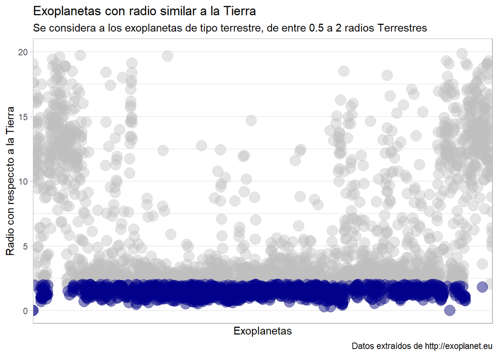

De la imagen anterior, es claro ver que existen muchos planetas extrasolares que entran en la categoría de Terrestre. Especificamente, 1319, un número no menor, por lo que bajo este criterio, no podemos señalar algún candidato específico, lo que significa que hay que seguir colocando restricciones.

### 2. ¿Cuál debería ser la masa un exoplaneta habitable?

Para el caso de la masa, no existe un criterio tan explícito como en el caso del radio. Por lo que aquí, se será más arbitrario, con el fin de seguir una línea investigativa.Por lo que se selecionará a aquellos exoplanetas cuya masa este entre 0.5 a 2 masas terrestres. Además, aquí nuevamente se da el dato con respecto a Júpiter, por lo que haciendo un procesamiento similar que con el radio, es posible plasmar los resultados en el siguiente gráfico:

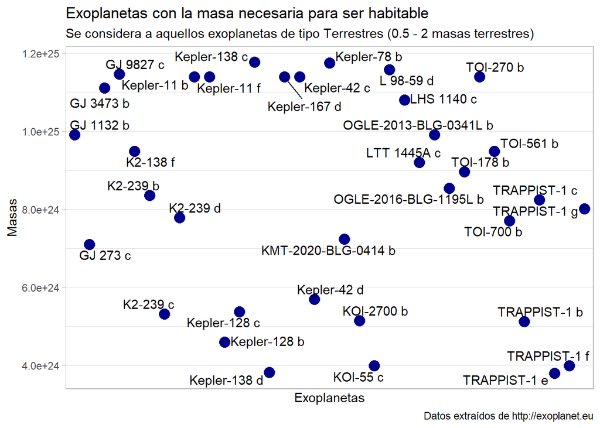

De la figura anterior, es posible hacer varias observaciones. Sin embargo, antes de profundizar en ello, es necesario saber que cuando se identifica una estrella que posee un sistema planetario los exoplanetas que lo componen pasan a tener el mismo nombre más una letra (comenzando en la b) que los identifique según su cercanía a dicha estrella. La relevancia de este dato se debe a que se puede comenzar a identificar algunos sistemas, solo al restringir la masa. Aquellos a los que les debemos prestar mayor atención son *K2-239*,*Keppler-11*, *Keppler-128*,*Keppler-138* y *TRAPPIST-1*

### 3. Temperatura de un exoplaneta habitable

Tal como se dijo anteriormente el rango de temperatura que se ocupará en este caso se encontrará entre los -5º y los 42º Celcius. Se ha seleccionado este rango por la simple razón de que son valores que han sido registrados en la Tierra y que el ser humano a logrado soportar, por lo que se considera un criterio lo bastante razonable. Sin embargo, la base de datos nos entrega este dato en grados Kelvin, lo hace que sea necesario una transformación a grados Celcius, para tener una mejor comprensión sobre los resultados. Lo que hará posible visualizar los datos en el siguiente gráfico:

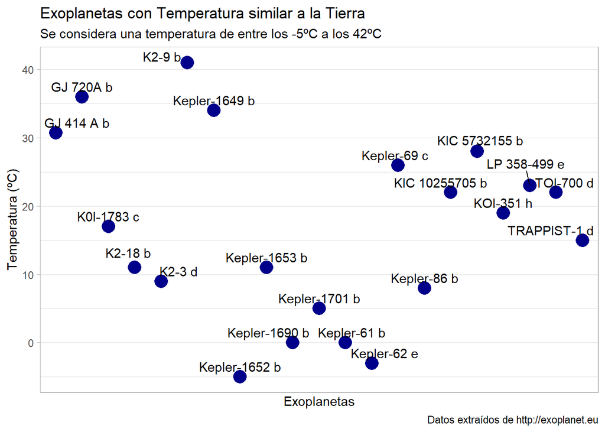

Según el gráfico, es posible observar que muchos de los nombres seleccionados anteriormente, no volvieron a aparecer. Lo cual se justifica en base a lo mencionado en un inicio, sobre que existe una gran cantidad de exoplanetas de los cuales no se tiene la suficiente información, lo que no implica que dejan de ser buenos candidatos. Al considerar esta nueva variable, se puede ver que el sistema planetario *TOI-700* y *TRAPPIST* comienzan a tomar cierta relevancia, ya que, su nombre se comienza a repetir. Por otro lado, dejando de un poco atrás el objetivo central del informe, es claro ver que el satélite Keppler es uno de los que más ha detectado planetas extrasolares con buenas características

### 4. Moléculas esenciales para la vida en un exoplaneta habitable

Como se mencionó, esta característica se enfocará solo en los planetas extrasolares que tengan agua dentro de su ecosistema, para ello usando diferentes funciones de R, lograremos identificar aquellos que la tengan y podrán ver en la siguiente tabla:

|  | nombre | moleculas |
| --- | --- | --- |
| 1 | 1RXS 1609 b | CO, H2O, K |
| 2 | 2I/Borisov | C2, CN, CO, H2O, NH2, O I, OH |
| 3 | 2M 2236+4751 b | CO, H2O |
| 4 | 51 Eri b | CH4, H2O |
| 5 | 51 Peg b | CO, H2O |
| 6 | 55 Cnc e | C2H2, H2O, HCN, N, NH3 |
| 7 | DH Tau b | CO, H2O |
| 8 | GJ 3470 b | CO, H, H2O, He |
| 9 | GJ 436 b | CH4, CO, CO2, H, H2O, Si |
| 10 | HAT-P-1 b | C, H2O, K, O I |
| 11 | HAT-P-26 b | CH4, CO, CO2, CrH, H2O, ScH, TiH |
| 12 | HD 102195 b | CH4, H2O |
| 13 | HD 179949 b | CO, H2O |
| 14 | HD 189733 b | C, CH4, CO, CO2, Fe I, H, H2O, He, K, Na, O, O I |
| 15 | HD 203030 b | H2O |
| 16 | HD 209458 b | C, C2H2, CH4, CO, CO2, Fe, H, H2, H2O, HCN, He, K, Mg, NH3, Na, O I, O2, TiO, VO |
| 17 | HR 8799 b | CH4, CO, H2O |
| 18 | HR 8799 c | H2O |
| 19 | K2-18 b | CH4, H2O, NH3 |
| 20 | kappa And b | H2O |
| 21 | KELT-11 b | H2O |
| 22 | KELT-7 b | H, H2O |
| 23 | Kepler-167 e | CH4, H2O, NH3 |
| 24 | Ross 458 (AB) c | CH4, H2, H2O, K |
| 25 | ROXs 42B (AB) b | CO, H2O, K |
| 26 | tau Boo A b | H2O |
| 27 | TRAPPIST-1 b | H2O |
| 28 | TRAPPIST-1 c | H2O |
| 29 | TRAPPIST-1 d | H2O |
| 30 | TRAPPIST-1 e | H2O |
| 31 | TRAPPIST-1 f | H2O |
| 32 | TRAPPIST-1 g | H2O |
| 33 | TRAPPIST-1 h | H2O |
| 34 | WASP-103 b | H2O, K, Na |
| 35 | WASP-12 b | C, CH4, CO, CO2, Ca, Fe, H, H2, H2O, HCN, He, Mg, Na, Ni, O I, SiO, Ti, TiO, VO |
| 36 | WASP-121 b | Ca, Fe, Fe I, H2O, Na, Ni, SH, SiO, Ti, TiO, VO |
| 37 | WASP-127 b | H2O, K, Li, Na |
| 38 | WASP-17 b | C, H2O, K, Na, O I, VO |
| 39 | WASP-18 b | CO, H, H2O |
| 40 | WASP-39 b | H2O |
| 41 | WASP-43 b | AlO, C, CH4, CO, CO2, H, H2O, K, KCl, NH3, O I, SiO, TiO2 |
| 42 | WASP-6 b | H2O, K, Na |
| 43 | WASP-76 b | Ca, Fe, H2O, He, Na, Ni, SiO, Ti, TiO, VO |
| 44 | WASP-80 b | CH4, CO, H, H2O, He, K, Na |
| 45 | WISE 1217+16 A b | CH4, H2, H2O |
| 46 | WISE J0458+6434 A | CH4, H2O |

# *¿Ahora qué?*

Lo presentado en este trabajo, es solo una pincelada de todo lo que se sabe de los planetas extrasolares. Esta breve sinopsis de la información solo debe motivarnos a seguir en la búsqueda de nuevos mundos, para aprender cada día algo sobre el universo.

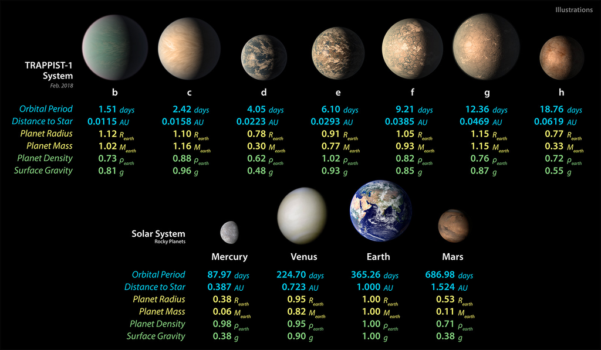

Crédito: NASA / JPL-Caltech

En conclusión, los exoplanetas son un objeto de estudio muy interesante que cada día va tomando mayor importancia al momento de hacer la investigación. Por otro lado, el sistema *TRAPPIST-1*, solo deja esperanzas para lo que se viene en el futuro de la ciencia, identificar planetas extrasolares es solo una parte de la misión, luego viene el mentalizar a todos los seres vivos de dejar sus vidas y emprenderse en este nuevo mundo. Sin embargo, eso ya se liga a otra rama de estudio que podría ser investigada en otro momento.

# *Referencias*

1. Exoplanet.eu. (1988–2021, noviembre 29). Exoplanet Catalog /Catalogue d’exoplanètes (semana del 08/10/2021) [Catálogo de todos los exoplanetas descubiertos hasta ahora (actualización semanal)]. Enciclopedia de planetas extrasolares http://exoplanet.eu. https://www.datastro.eu/explore/dataset/exoplaneteu_catalog-1/table/?sort=updated

2. H. Wickham. *ggplot2: Elegant Graphics for Data Analysis.* Springer-Verlag New York, 2016.

3. Hadley Wickham (2019). *stringr: Simple, Consistent Wrappers for Common String Operations.* R package version 1.4.0. https://CRAN.R-project.org/package=stringr

4. Hadley Wickham, Romain François, Lionel Henry and Kirill Müller (2021). *dplyr: A Grammar of Data Manipulation.* R package version 1.0.7. https://CRAN.R-project.org/package=dplyr

5. Hao Zhu (2021). k*ableExtra: Construct Complex Table with ‘kable’ and Pipe Syntax.* R package version 1.3.4. https://CRAN.R-project.org/package=kableExtra

6. Hiroaki Yutani (2021). *gghighlight: Highlight Lines and Points in ‘ggplot2’.* R package version 0.3.2. https://CRAN.R-project.org/package=gghighlight

7. Kamil Slowikowski (2021). *ggrepel: Automatically Position Non-Overlapping Text Labels with ‘ggplot2’.* R package version 0.9.1. https://CRAN.R-project.org/package=ggrepel

8. Kirill Müller (2020). *here: A Simpler Way to Find Your Files.* R package version 1.0.1. https://CRAN.R-project.org/package=here

9. NASA. (s. f.-a). *Overview | what is an exoplanet?* Exoplanet Exploration: Planets Beyond our Solar System. Recuperado 1 de diciembre de 2021, de https://exoplanets.nasa.gov/what-is-an-exoplanet/overview/

10. NASA. (s. f.-b). *Terrestrial | planet types.* Exoplanet Exploration: Planets Beyond our Solar System. Recuperado 1 de diciembre de 2021, de https://exoplanets.nasa.gov/what-is-an-exoplanet/planet-types/terrestrial/

11. NASA. (2017, 21 febrero). *NASA telescope reveals largest batch of earth-size, habitable-zone planets around single star.* Exoplanet Exploration: Planets Beyond our Solar System. Recuperado 1 de diciembre de 2021, de https://exoplanets.nasa.gov/news/1419/nasa-telescope-reveals-largest-batch-of-earth-size-habitable-zone-planets-around-single-star/

12. Olivares Peréz, A. (2017, 9 octubre). *Tamaños y distancias en el Sistema Solar con respecto a nuestro planeta.* Saberes y Ciencias. Recuperado 1 de diciembre de 2021, de https://saberesyciencias.com.mx/2017/10/09/tamanos-distancias-sistema-solar-respecto-planeta/